# BME4550_Fall2018_Assignment1

### 5. What happens if you make a scatterplot of class vs drv? Why is the plot not useful?

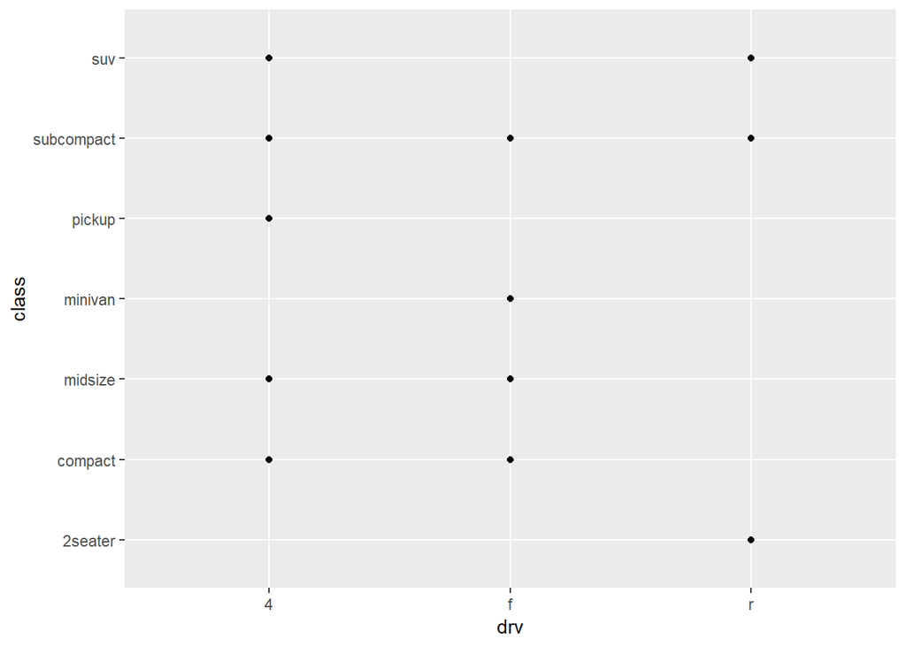

```r
ggplot(data=mpg) + geom_point(mapping = aes(x=drv,y=class))
```

It is not a very helpful graph because both the x and y variables are unordered/discrete/qualitative.

## 3.3.1 Exercises

### 1. What’s gone wrong with this code? Why are the points not blue?

The points are not blue because they included the color = “blue” inside of the aes. In order to make all the points blue, you would use the following code.

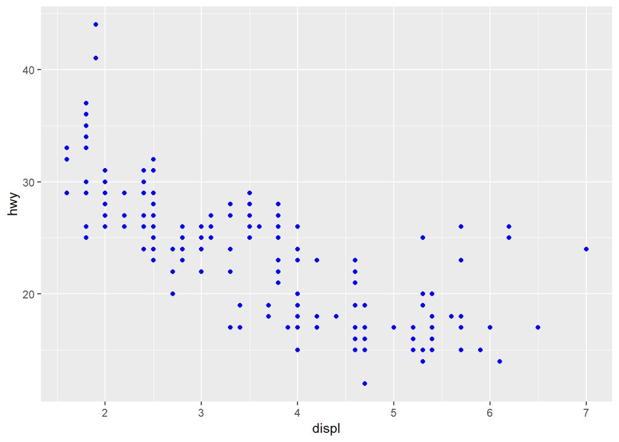

```r
ggplot(data=mpg) + geom_point(mapping = aes(x = displ, y= hwy),color="blue")
```

### 2. Which variables in mpg are categorical? Which variables are continuous? (Hint: type ?mpg to read the documentation for the dataset). How can you see this information when you run mpg?

```r
mpg
```

```
## # A tibble: 234 x 11
##    manufacturer model displ  year   cyl trans drv     cty   hwy fl    cla~
##    <chr>        <chr> <dbl> <int> <int> <chr> <chr> <int> <int> <chr> <ch>
##  1 audi         a4      1.8  1999     4 auto~ f        18    29 p     com~
##  2 audi         a4      1.8  1999     4 manu~ f        21    29 p     com~
##  3 audi         a4      2    2008     4 manu~ f        20    31 p     com~
##  4 audi         a4      2    2008     4 auto~ f        21    30 p     com~
##  5 audi         a4      2.8  1999     6 auto~ f        16    26 p     com~
##  6 audi         a4      2.8  1999     6 manu~ f        18    26 p     com~
##  7 audi         a4      3.1  2008     6 auto~ f        18    27 p     com~
##  8 audi         a4 q~   1.8  1999     4 manu~ 4        18    26 p     com~
##  9 audi         a4 q~   1.8  1999     4 auto~ 4        16    25 p     com~
## 10 audi         a4 q~   2    2008     4 manu~ 4        20    28 p     com~
## # ... with 224 more rows
```

Categorical: manufacturer, model trans, drv, fl, class Continuous: displ, year, cyl, cty, hwy

The way to determine between the two was whether the variable data type was chr or int.

### 3. Map a continuous variable to color, size, and shape. How do these aesthetics behave differently for categorical vs. continuous variables?

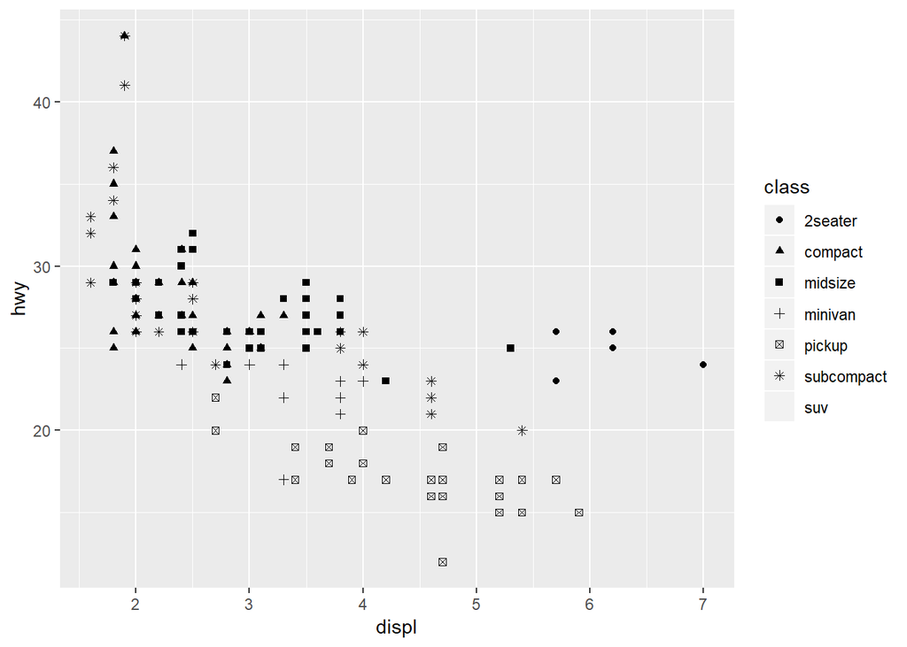

```r
ggplot(data=mpg) + geom_point(mapping=aes(x=displ,y=hwy,shape=class))
```

```r
#ggplot(data=mpg) + geom_point(mapping=aes(x=displ,y=hwy,shape=cty))
```

```
## Warning: Using size for a discrete variable is not advised.
```

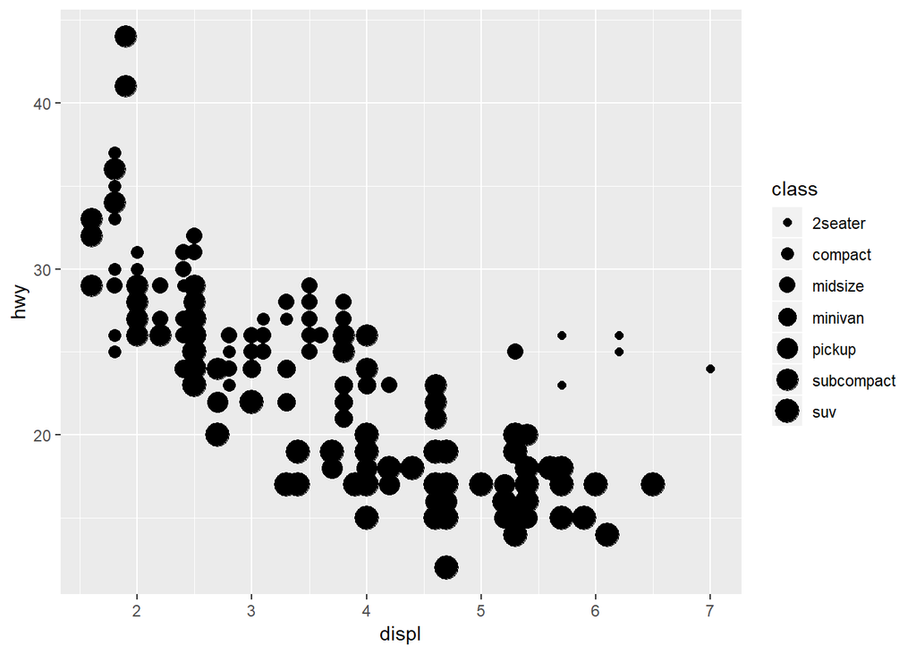

```r
ggplot(data=mpg) + geom_point(mapping=aes(x=displ,y=hwy,size=class))
```

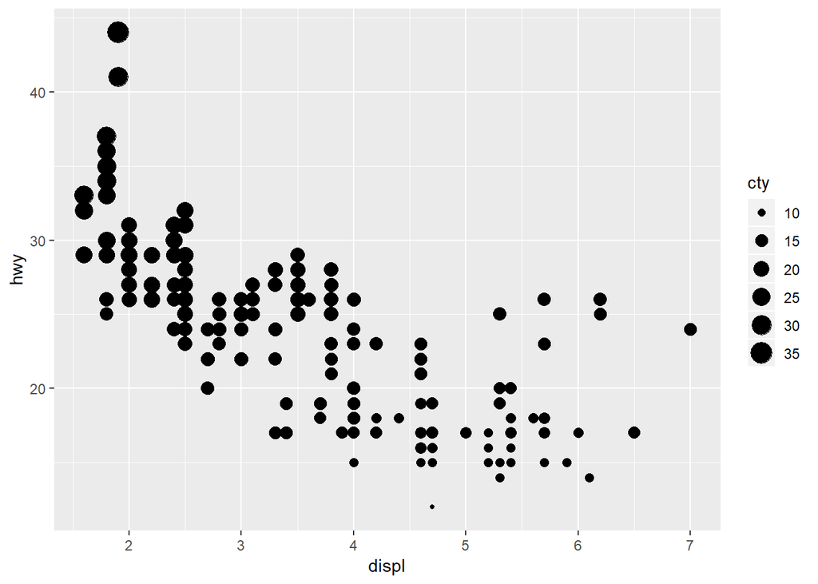

```r
ggplot(data=mpg) + geom_point(mapping=aes(x=displ,y=hwy,size=cty))
```

When you use size on a categorical variable, it will give you a warning, but will still run. There is no good way to assign something like a color to a size, how would one decide what colors should be larger than others? Size works great for continuous data because the larger values will result in a bigger data point.

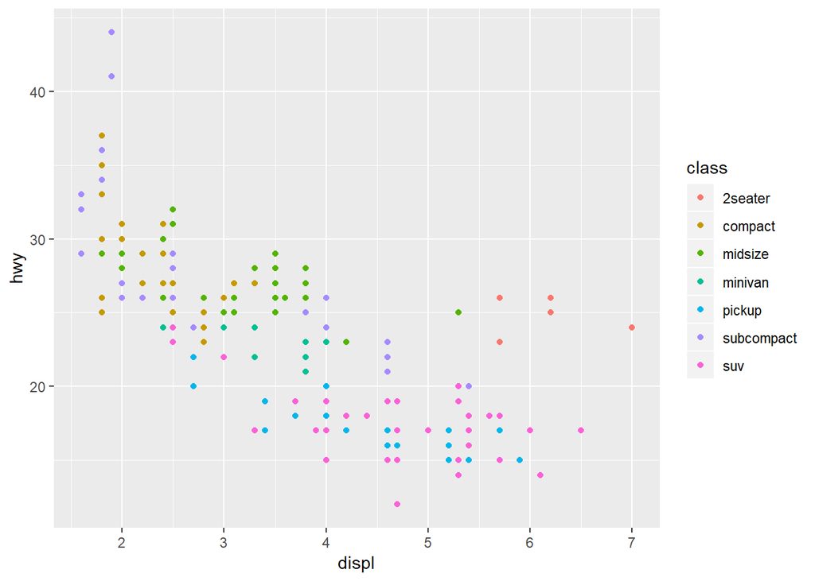

```r
ggplot(data=mpg) + geom_point(mapping=aes(x=displ,y=hwy,color=class))
```

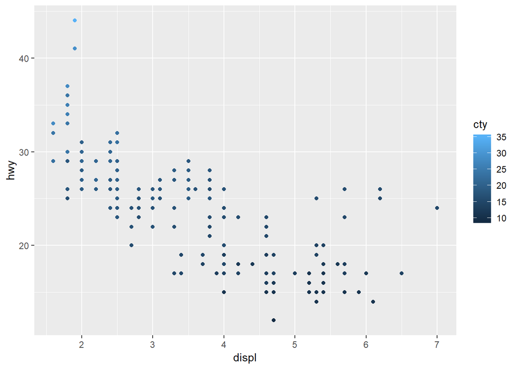

```r
ggplot(data=mpg) + geom_point(mapping=aes(x=displ,y=hwy,color=cty))
```

When you use color on a categorical variable, it assigns each different observation as a different color, while if you use it on a continuous variable, it creates a color gradient, where the size of the number correlates to the intensity of the color.

### 4. What happens if you map the same variable to multiple aesthetics?

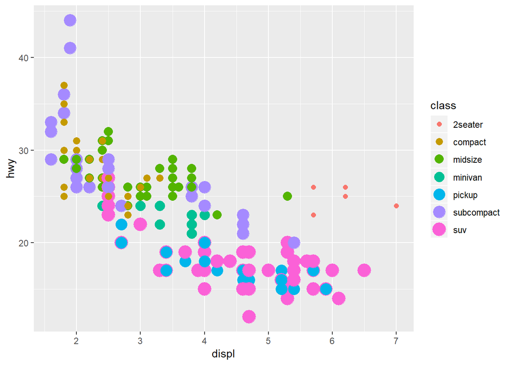

```r
ggplot(data=mpg) + geom_point(mapping=aes(x=displ,y=hwy,color=class,size=class))
```

If you use multiple aes on a single variable, it will apply both. Therefore if it assigned a single observation as blue and a large size, then it’ll be a large blue dot, while another one might be a small red dot.

### 5. What does the stroke aesthetic do? What shapes does it work with?

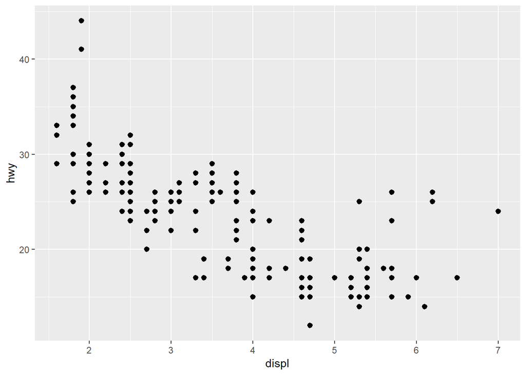

```r
ggplot(data=mpg) + geom_point(mapping=aes(x=displ,y=hwy, stroke = 1))
```

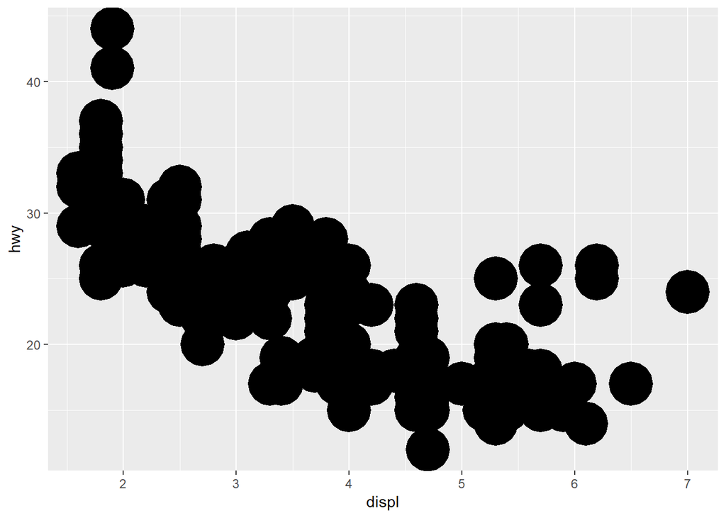

```r
ggplot(data=mpg) + geom_point(mapping=aes(x=displ,y=hwy, stroke = 10))
```

```r
ggplot(data=mpg) + geom_smooth(mapping=aes(x=displ,y=hwy, stroke = 10))
ggplot(data=mpg) + geom_smooth(mapping=aes(x=displ,y=hwy, stroke = 1))
```

[output not shown]

### 6. What happens if you map an aesthetic to something other than a variable name, like aes(colour = displ < 5)?

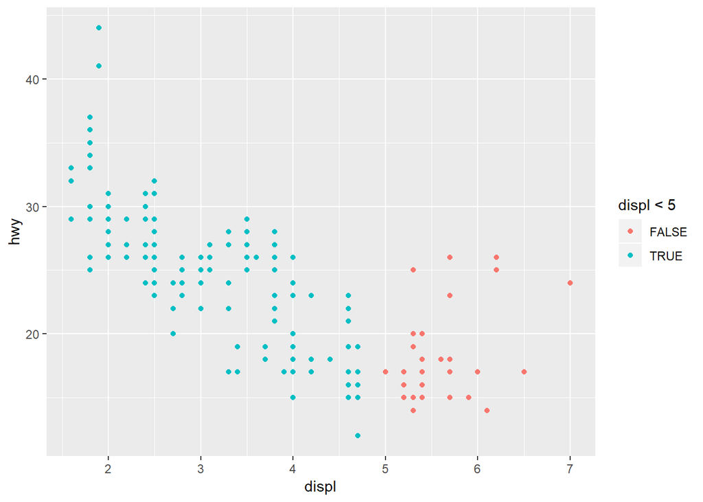

```r
ggplot(data=mpg) + geom_point(mapping = aes(x=displ,y=hwy,color=displ<5))
```

By adding “colour = displ < 5” to our aesthetic, a logical is created. A color is then assigned to true and false and the plot is colored accordingly.

## 3.5.1 Exercises

### 1. What happens if you facet on a continuous variable?

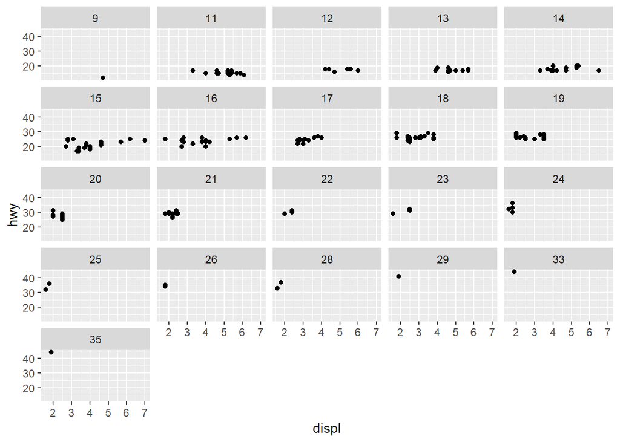

```r
ggplot(data=mpg) + geom_point(mapping = aes(x=displ, y=hwy)) + facet_wrap(~ cty)
```

Running facet on a continuous variable creates a new plot for each of the observation values for that variable found in the data set. For example, all the different observations that had a different city miles per gallon got their own plot.

### 2. What do the empty cells in plot with facet_grid(drv ~ cyl) mean? How do they relate to this plot?

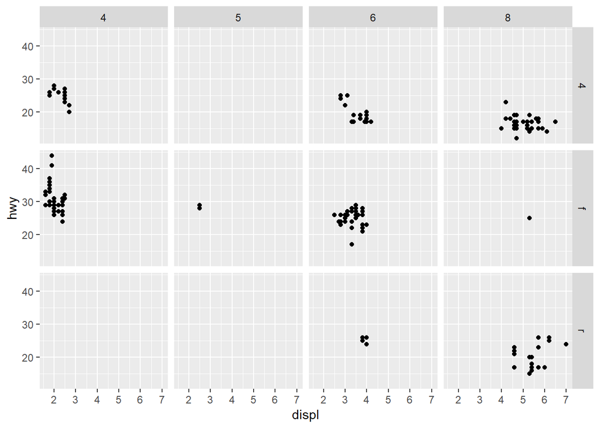

```r
ggplot(data=mpg) + geom_point(mapping = aes(x=displ, y=hwy)) + facet_grid(drv ~ cyl)
```

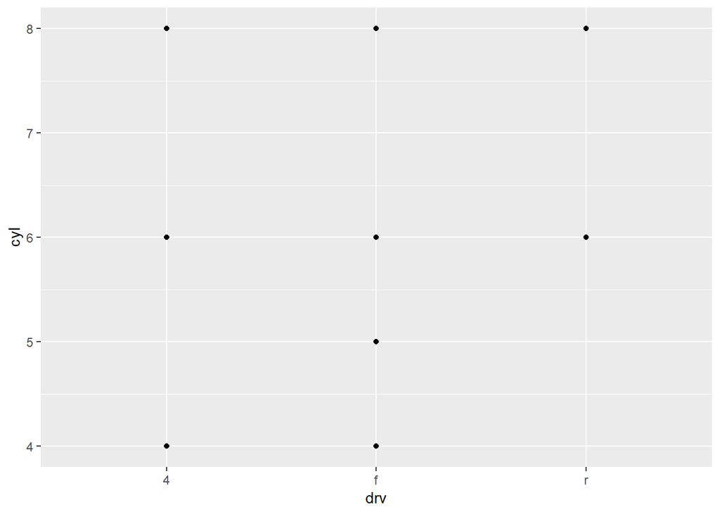

```r
ggplot(data = mpg) + geom_point(mapping = aes(x = drv, y = cyl))
```

The empty cells represent combinations between the two variables that are not present in the data set. The two plots are related because in both of them the empty intersections or grids are the combinations that are not present. For example, in the data set, there are no cars that have both 4 wheel drive and 5 cylinders.

### 3. What plots does the following code make? What does . do?

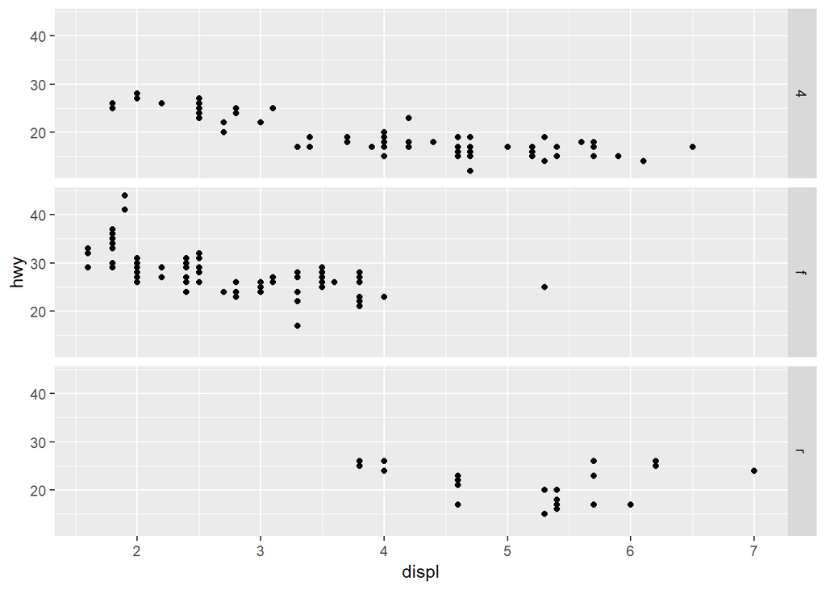

```r
ggplot(data = mpg) +
  geom_point(mapping = aes(x = displ, y = hwy)) +
  facet_grid(drv ~ .)
```

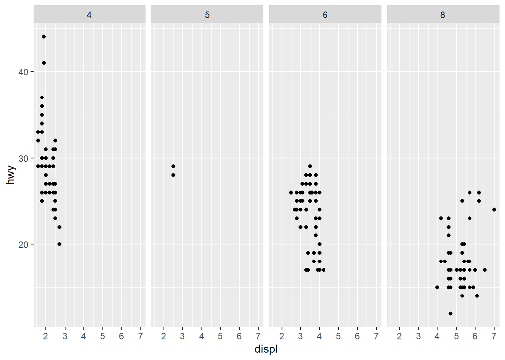

```r
ggplot(data = mpg) +
  geom_point(mapping = aes(x = displ, y = hwy)) +
  facet_grid(. ~ cyl)
```

### 4. What are the advantages to using faceting instead of the colour aesthetic? What are the disadvantages? How might the balance change if you had a larger dataset?

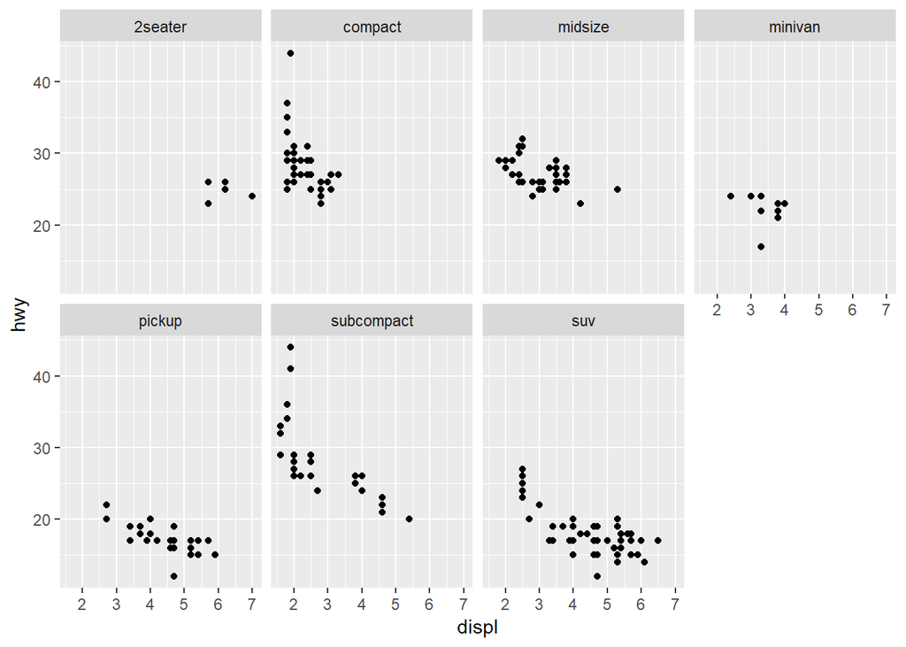

```r
ggplot(data = mpg) +
  geom_point(mapping = aes(x = displ, y = hwy)) +
  facet_wrap(~ class, nrow = 2)
```

The advantages of using faceting instead of colour is that it allows for easier comparisons amongst the individual groups. A disadvantage would be colour allows for easier and broader comparisons amongst the different classes. As the size of the data sets increase, the advantages and disadvantages of both methods become more appearent. If you had thousands of points separated by color on one plot, it would be very difficult to focus on one class’s values. On the other hand, there are a limited amount of colors we can distinguish between easily, but we can create an endless amount of facets, so once the data set contains many more categories, facets become more helpful.

### 5. Read ?facet_wrap. What does nrow do? What does ncol do? What other options control the layout of the individual panels? Why doesn’t facet_grid() have nrow and ncol arguments?

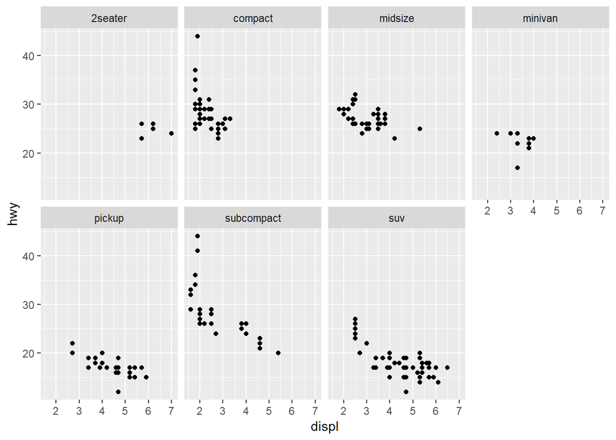

```r
#?facet_wrap
ggplot(data = mpg) +
  geom_point(mapping = aes(x = displ, y = hwy)) +
  facet_wrap(~ class, nrow = 2)
```

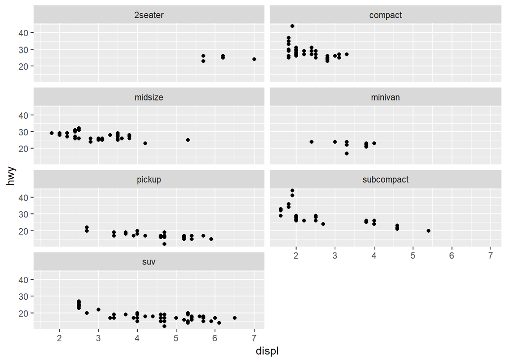

```r
ggplot(data = mpg) +
  geom_point(mapping = aes(x = displ, y = hwy)) +
  facet_wrap(~ class, ncol = 2)
```

nrow and ncol allow you to set the number of rows and columns that facet will break the data into. The direction “dir” argument in facet_wrap controls the whether the plots are horizontal or vertical. facet_grid does not have nrow and ncol arguments because those values are set by the number of unique observations in the variable data sets.

### 6. When using facet_grid() you should usually put the variable with more unique levels in the columns. Why?

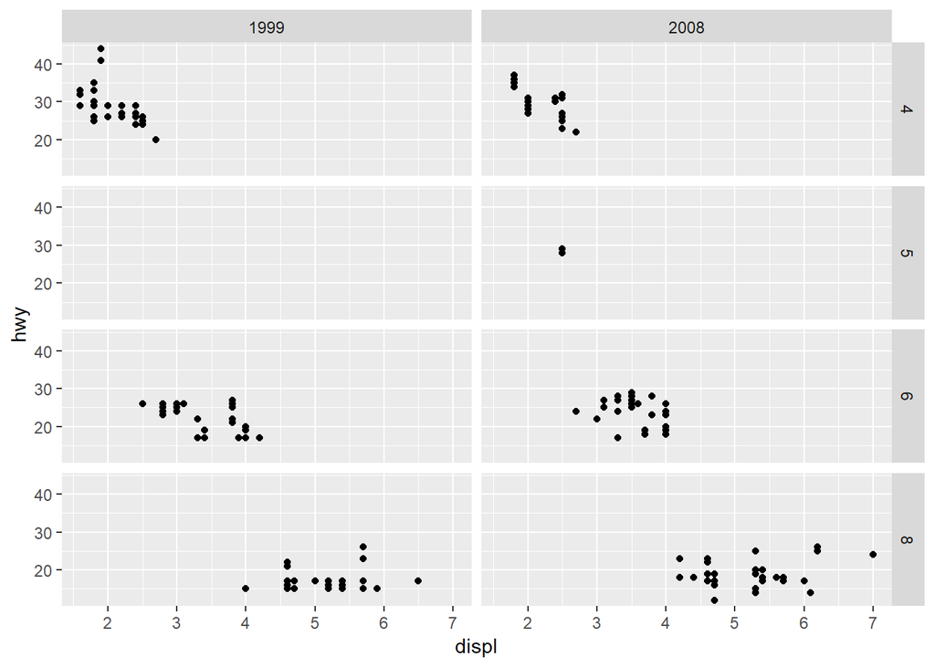

```r
ggplot(data=mpg) + geom_point(mapping = aes(x = displ, y=hwy)) + facet_grid(cyl ~ year)
```

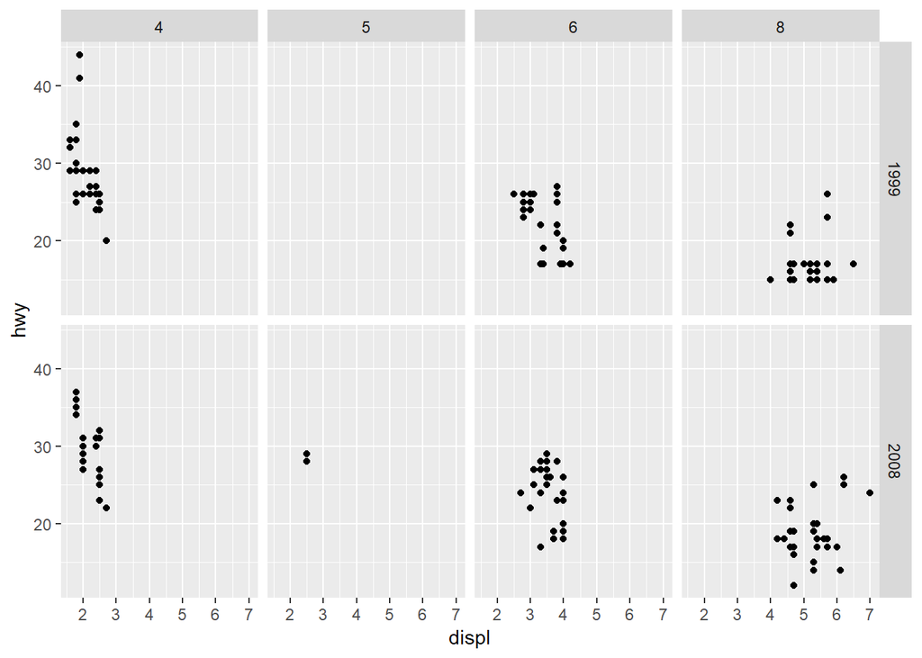

```r
ggplot(data=mpg) + geom_point(mapping = aes(x = displ, y=hwy)) + facet_grid(year ~ cyl)
```

Most computer screens are wider than they are tall, so you want the graphs to be able to stretch out as far as they can and just be able to scroll down between the different facets, instead of having squished plots.

## 3.6.1 Exercises

### 1. What geom would you use to draw a line chart? A boxplot? A histogram? An area chart?

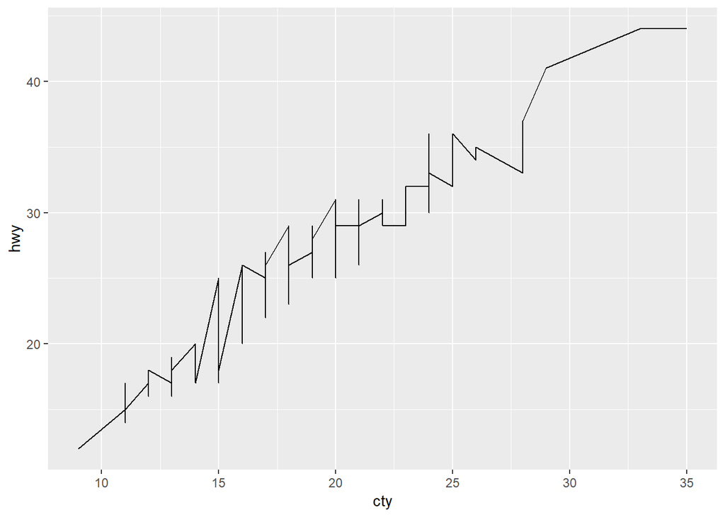

```r
ggplot(data = mpg, mapping = aes(x = cty, y = hwy)) + geom_line()
```

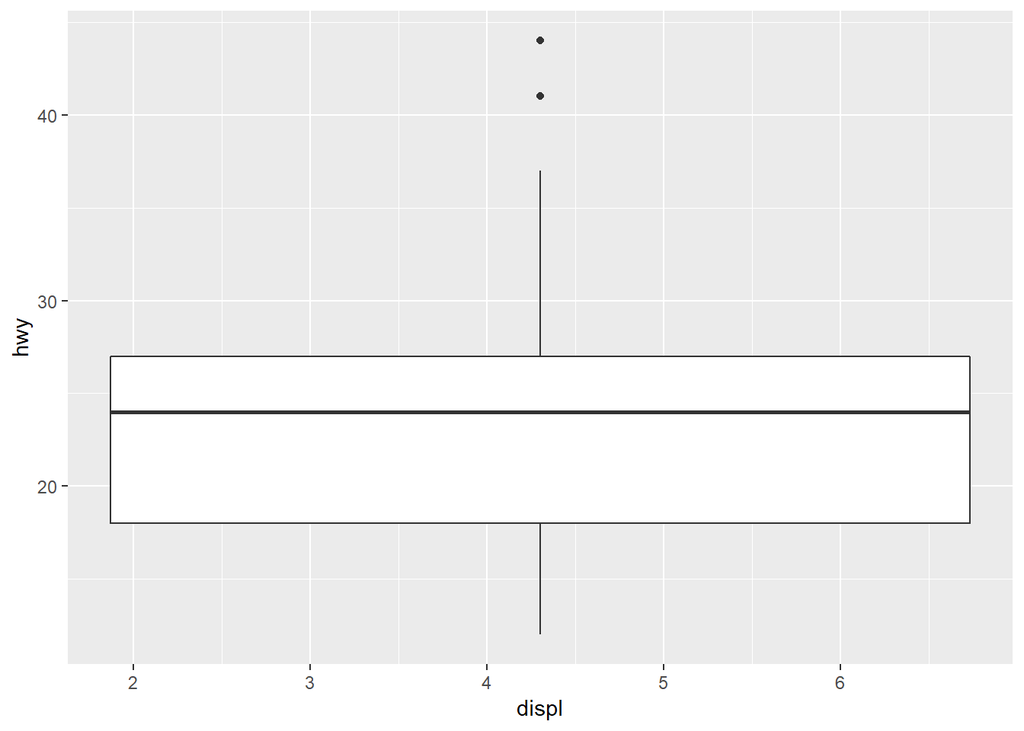

```r
ggplot(data = mpg, mapping = aes(x = displ, y = hwy)) + geom_boxplot()
```

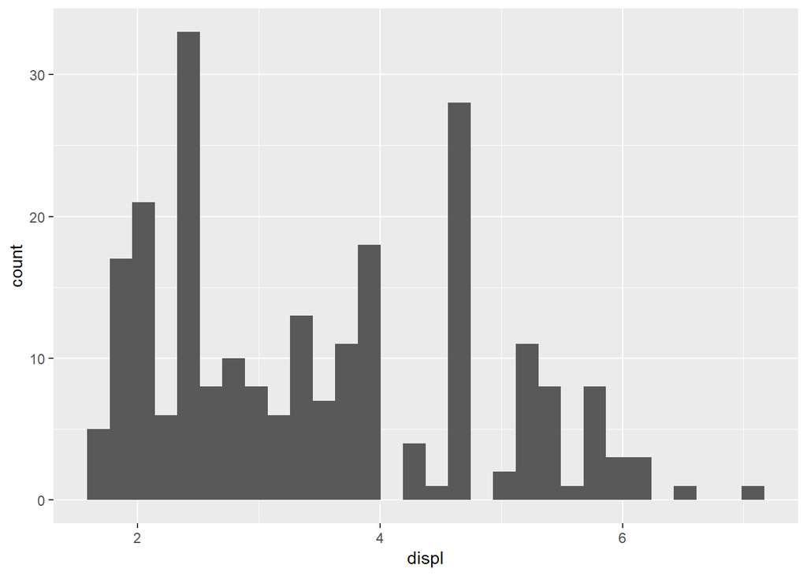

```r
ggplot(data = mpg) + geom_histogram(mapping = aes(x=displ))
```

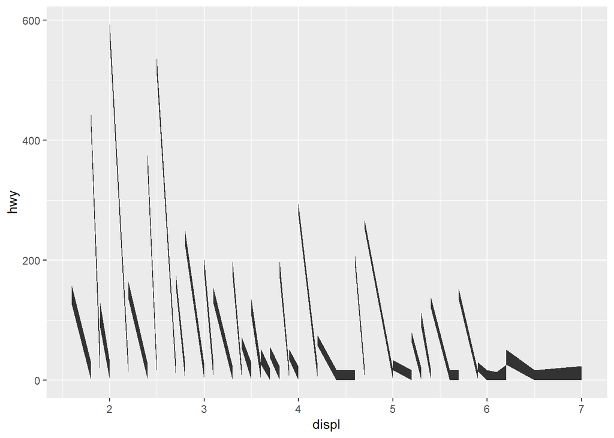

```r
ggplot(data = mpg, mapping = aes(x = displ, y = hwy)) + geom_area()
```

geom_line for line geom_boxplot for boxplots geom_histogram for histograms(only accepts one variable) geom_area for area

### 2. Run this code in your head and predict what the output will look like. Then, run the code in R and check your predictions.

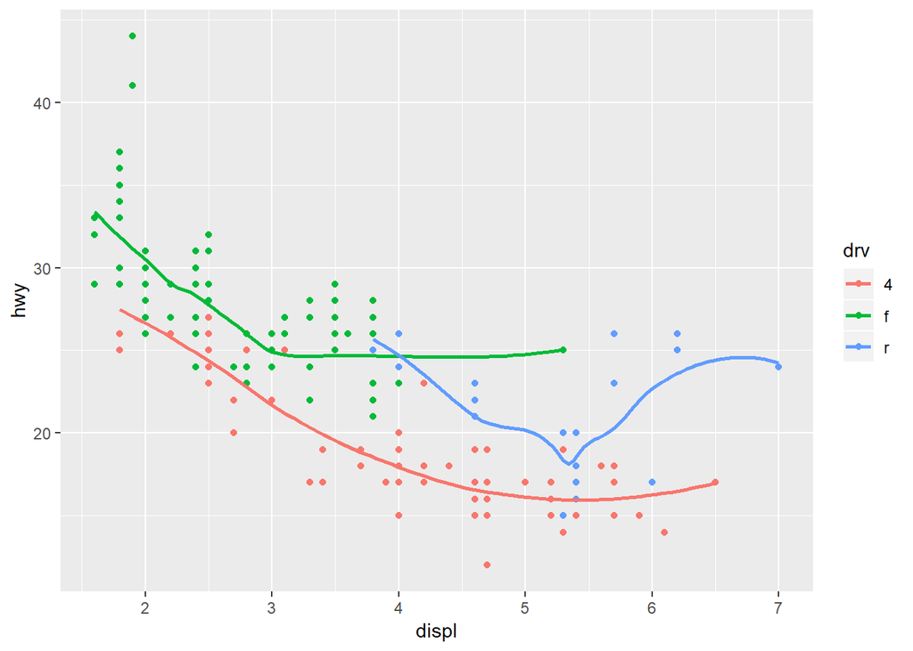

```r
ggplot(data = mpg, mapping = aes(x = displ, y = hwy, color = drv)) +
  geom_point() +
  geom_smooth(se = FALSE)
```

This will generate a plot that graphs a scatterplot of displ and hwy for all the points and then differentiates between the three different classes of drv by coloring the dots based on what wheel drive they are. Three different smooth curve fits will then be plotted, one for each of the different drv classes, and matching the same color as the corresponding class’s dots. Also, the se=False makes it so no confidence intervals around the smooth fit are shown.

### 3. What does show.legend = FALSE do? What happens if you remove it? Why do you think I used it earlier in the chapter?

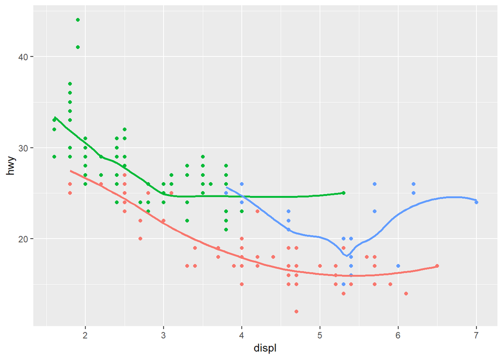

```r
ggplot(data = mpg, mapping = aes(x = displ, y = hwy, color = drv)) +
  geom_point(show.legend = FALSE) +
  geom_smooth(se = FALSE, show.legend = FALSE)
```

show.legend is by default on if there are any mapped aesthetics and it creates a legend that allows the reader to know what color or shape is for what variable observation. If you use show.legend = FALSE, the aesthetics stay, but the legend goes away. It might have been used earlier in the chapter to make more minimaistic graphs that were used to teach us some specific skill that the legend was not important for or could have added confusion.

### 4. What does the se argument to geom_smooth() do?

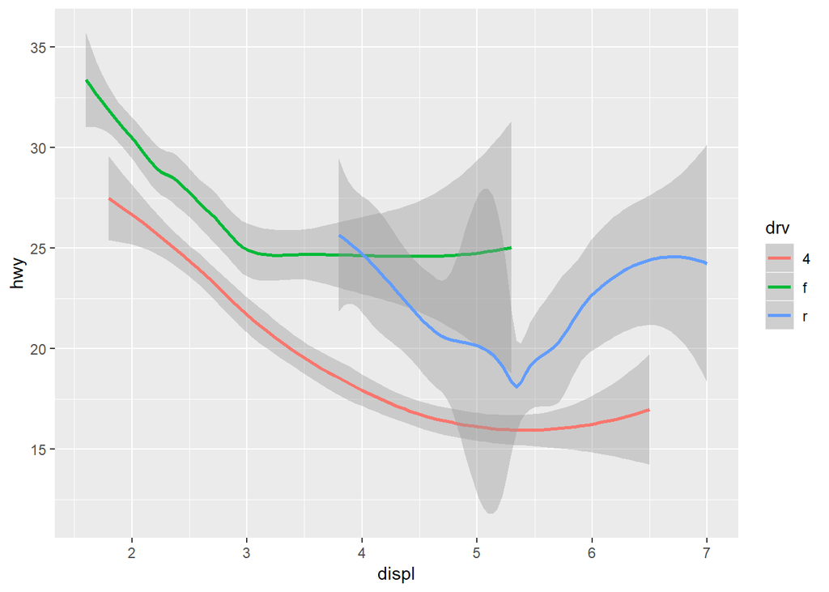

```r
ggplot(data=mpg, mapping=aes(x=displ,y=hwy,color=drv)) + geom_smooth(se=TRUE)
```

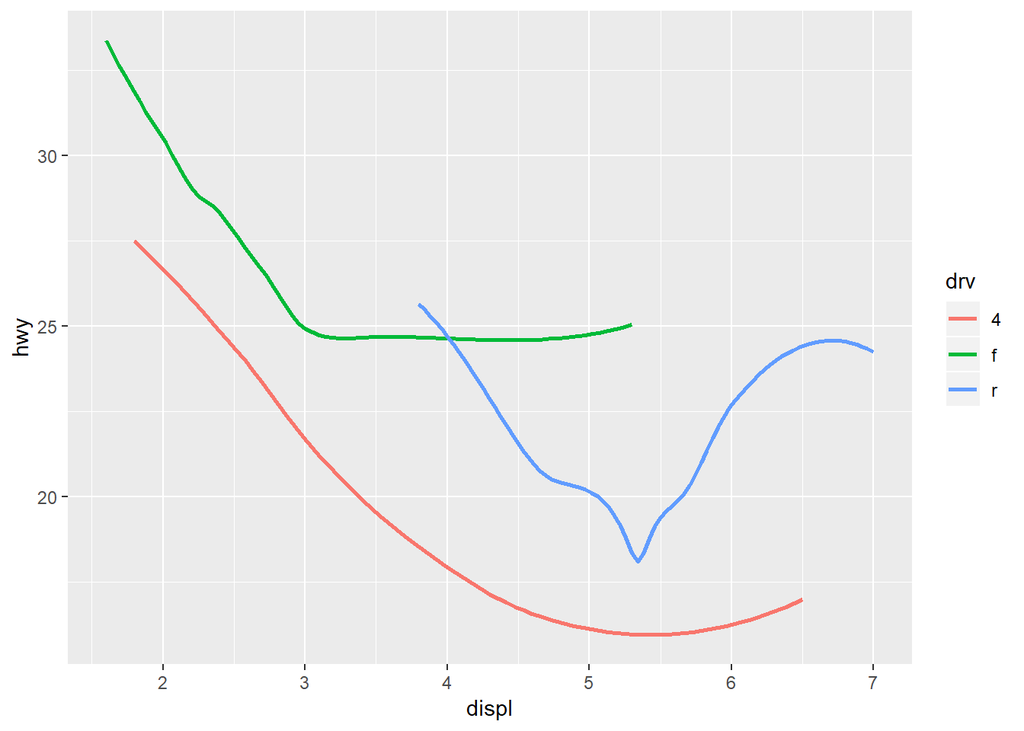

```r
ggplot(data=mpg, mapping=aes(x=displ,y=hwy,color=drv)) + geom_smooth(se=FALSE)
```

se takes a logical and allows you to choose whether or not to display the confidence intervals around the smooth curve.